# IE.425 PROJECT

### Kaan Aslan 2017402087 | Serdar Yıldız 2017402033

## Introduction

Kobe was one of the best basketball players around the world and had the shot accuracy of 44%. Kobe was famous for his ambition and also he was the player with record of number of shots he made. In this project, the aim is predicting whether his shot went in or not. The data provided consist of attributes with information about location, time and match which will be used to construct data mining models. First, necessary data manipulations will be applied, then the features will be selected and models will be built. Depending on the performance measure, ROC value, the bets model will be selected and predictions will be made.

### Data Manipulation and Required Packages

```r
library(data.table)
library(caTools)
library(caret)
library(randomForest)
library(gbm)
library(dplyr)
library(Metrics)
library(ranger)
library(rpart)
library(xgboost)
library(ROCR)
```

```r
data <- fread("C:/Users/kaan9/OneDrive/Masaüstü/IE425/kobe-train.csv",stringsAsFactors = TRUE)
data$season_general <- as.factor(case_when(data$season %in% c('1996-97','1997-98','1998-99','1999-00') ~ 1,
                                           data$season %in% c('2000-01','2001-02','2002-03','2003-04') ~ 2,
                                           data$season %in% c('2004-05','2005-06','2006-07','2007-08') ~ 3,
                                           data$season %in% c('2008-09','2009-10','2010-11','2011-12') ~ 4,
                                           data$season %in% c('2012-13','2013-14','2014-15','2015-16') ~ 5))
data$action_t <- as.character(data$action_type)
data[grepl("dunk",data$action_type,ignore.case = TRUE)]$action_t <- "DUNK"
data$action_t <- as.factor(data$action_t)
data$game_date <- as.Date(data$game_date,"%d.%m.%Y")
data$period <- as.factor(data$period)
data$game_event_id <- as.factor(data$game_event_id)
data$game_id <- as.factor(data$game_id)
data$remaining_time <- data$minutes_remaining*60 - data$seconds_remaining
data$shot_made_flag <- as.factor(data$shot_made_flag)
levels(data$shot_made_flag) <- c("NO","YES")
data$playoffs <- as.factor(data$playoffs)
levels(data$shot_zone_range) <- c("16-24 ft.","About 24 ft.","8-16 ft.","Long Shot","Less Than 8 ft.")
data[data$loc_y>300,]$shot_zone_range <- "Long Shot"
levels(data$shot_zone_area) <- c("Away","Center(C)","Left Side Center(LC)","Left Side(L)","Right Side Center(RC)","Right Side(R)")
data[data$loc_y>300,]$shot_zone_area <- "Away"
data$is_home <- 0
data[grepl("vs.",data$matchup,ignore.case = TRUE)]$is_home <- 1
```

```r
data_test <- fread("C:/Users/kaan9/OneDrive/Masaüstü/IE425/kobe-test.csv",stringsAsFactors = TRUE)
data_test$season_general <- as.factor(case_when(data_test$season %in% c('1996-97','1997-98','1998-99','1999-00') ~ 1,
                                           data_test$season %in% c('2000-01','2001-02','2002-03','2003-04') ~ 2,
                                           data_test$season %in% c('2004-05','2005-06','2006-07','2007-08') ~ 3,
                                           data_test$season %in% c('2008-09','2009-10','2010-11','2011-12') ~ 4,
                                           data_test$season %in% c('2012-13','2013-14','2014-15','2015-16') ~ 5))
data_test$action_t <- as.character(data_test$action_type)
data_test[grepl("dunk",data_test$action_type,ignore.case = TRUE)]$action_t <- "DUNK"
data_test$action_t <- as.factor(data_test$action_t)
data_test$game_date <- as.Date(data_test$game_date,"%d.%m.%Y")
data_test$period <- as.factor(data_test$period)
data_test$game_event_id <- as.factor(data_test$game_event_id)
data_test$game_id <- as.factor(data_test$game_id)
data_test$remaining_time <- data_test$minutes_remaining*60 - data_test$seconds_remaining
data_test$playoffs <- as.factor(data_test$playoffs)
levels(data_test$shot_zone_range) <- c("16-24 ft.","About 24 ft.","8-16 ft.","Long Shot","Less Than 8 ft.")
data_test[data_test$loc_y>300,]$shot_zone_range <- "Long Shot"
levels(data_test$shot_zone_area) <- c("Away","Center(C)","Left Side Center(LC)","Left Side(L)","Right Side Center(RC)","Right Side(R)")
data_test[data_test$loc_y>300,]$shot_zone_area <- "Away"
data_test$is_home <- 0
data_test[grepl("vs.",data_test$matchup,ignore.case = TRUE)]$is_home <- 1
```

### Feature Selection

Feature selection and data manipulation is one of the most important parts to build acurate models. While some of the variables are numeric, most of the columns are categorical. Neccesary data type transformations applied above. First, overall effects of the variables could be measured with a simple logistic regression model which could give important insights of the data.

```r
features1 <- data[,c(-1,-4,-5,-21,-22,-24,-29:-26)]
```

Features 1 consists of the original variables but shot_id, game_event_id, team_id, team_name and matchup columns are removed. These variables can not explain the output variable.

```r
glm_test1 <- glm(shot_made_flag~.,data=features1)
summary(glm_test1)
```

```
Call:
glm(formula = shot_made_flag ~ ., data = features1)

Deviance Residuals:
    Min       1Q   Median       3Q      Max
-1.0582  -0.3550  -0.2624   0.4450   1.0184

Coefficients: (9 not defined because of singularities)
                                             Estimate Std. Error t value
(Intercept)                                -8.255e-01  3.718e+00  -0.222
action_typeAlley Oop Layup shot            -2.483e-01  7.521e-02  -3.302
action_typeCutting Layup Shot              -1.624e-01  1.946e-01  -0.835
action_typeTurnaround Bank shot            -1.377e-01  8.485e-02  -1.622
action_typeTurnaround Fadeaway shot        -3.268e-01  6.204e-02  -5.267
action_typeTurnaround Finger Roll Shot     -6.509e-03  4.614e-01  -0.014
action_typeTurnaround Hook Shot            -4.060e-01  1.719e-01  -2.362
action_typeTurnaround Jump Shot            -3.648e-01  5.833e-02  -6.254
....
combined_shot_typeDunk                             NA         NA      NA
combined_shot_typeHook Shot                        NA         NA      NA
combined_shot_typeJump Shot                        NA         NA      NA
combined_shot_typeLayup                            NA         NA      NA
combined_shot_typeTip Shot                         NA         NA      NA
lat                                         5.479e-02  1.074e-01   0.510
loc_x                                      -4.179e-05  8.507e-05  -0.491
loc_y                                              NA         NA      NA
lon                                                NA         NA      NA
minutes_remaining                           3.166e-03  9.010e-04   3.514
period2                                    -9.371e-03  8.815e-03  -1.063
period3                                    -1.423e-02  8.292e-03  -1.717
period4                                    -4.484e-02  8.684e-03  -5.163
period5                                    -1.701e-02  3.000e-02  -0.567
period6                                     3.836e-02  8.885e-02   0.432
period7                                    -3.729e-02  1.745e-01  -0.214
playoffs1                                  -2.388e-03  1.196e-02  -0.200
season1997-98                               9.335e-03  3.991e-02   0.234
season1998-99                               8.703e-02  6.185e-02   1.407
season1999-00                               9.736e-02  8.157e-02   1.194
season2000-01                               1.130e-01  1.039e-01   1.088
season2001-02                               1.308e-01  1.290e-01   1.014
```

[output cut: 23 more lines]

```
opponentCHA                                 1.602e-02  3.158e-02   0.507
opponentCHI                                 1.640e-02  3.156e-02   0.519
opponentCLE                                 1.784e-03  3.121e-02   0.057
....

---
Signif. codes:  0 '***' 0.001 '**' 0.01 '*' 0.05 '.' 0.1 ' ' 1

(Dispersion parameter for gaussian family taken to be 0.2101295)

    Null deviance: 5714.7  on 23126  degrees of freedom
Residual deviance: 4831.7  on 22994  degrees of freedom
AIC: 29687

Number of Fisher Scoring iterations: 2
```

According to the logistic regression model, combined_shot_type gives NA which means pure correlation. Combined_shot_type must be correlated with action_type because its sub-class of it. Latitude and longitude variables are also purely correlated with loc_x and loc_y variables. Those could be removed from the data. Loc_x, loc_y, shot_zone_area, shot_zone_range, shot_distance are the variables about the location of the player. Final model should consist of some of them. Loc_x and Loc_y could be separated from the others because they are actual locations and continuous variables. Also, season gives information about the game_date and age of the player. So, only taking season is enough for a time variable

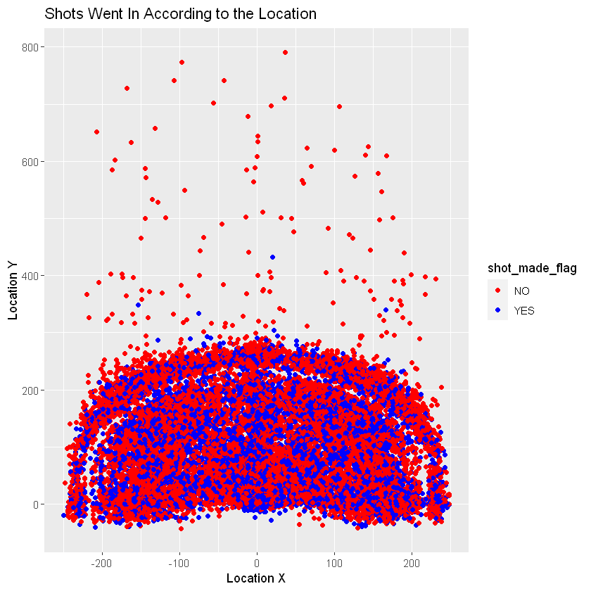

```r
ggplot(data,aes(x=loc_x,y=loc_y,color=shot_made_flag)) + geom_point() +
labs(title= "Shots Went In According to the Location", x="Location X",y="Location Y") +
scale_color_manual(values=c("NO"="red","YES"="blue"))
```

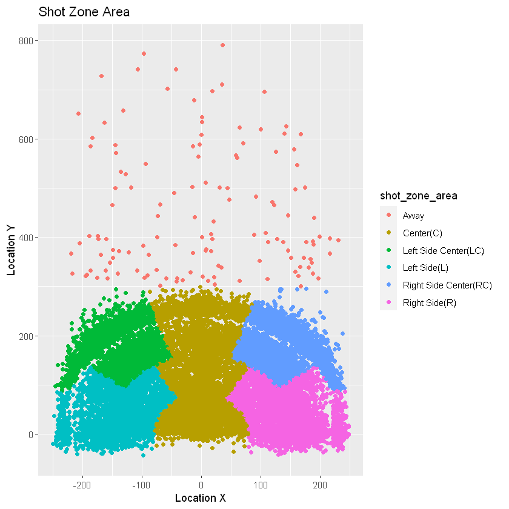

```r
ggplot(data,aes(x=loc_x,y=loc_y,color=shot_zone_area)) + geom_point() +
labs(title= "Shot Zone Area", x="Location X",y="Location Y")
```

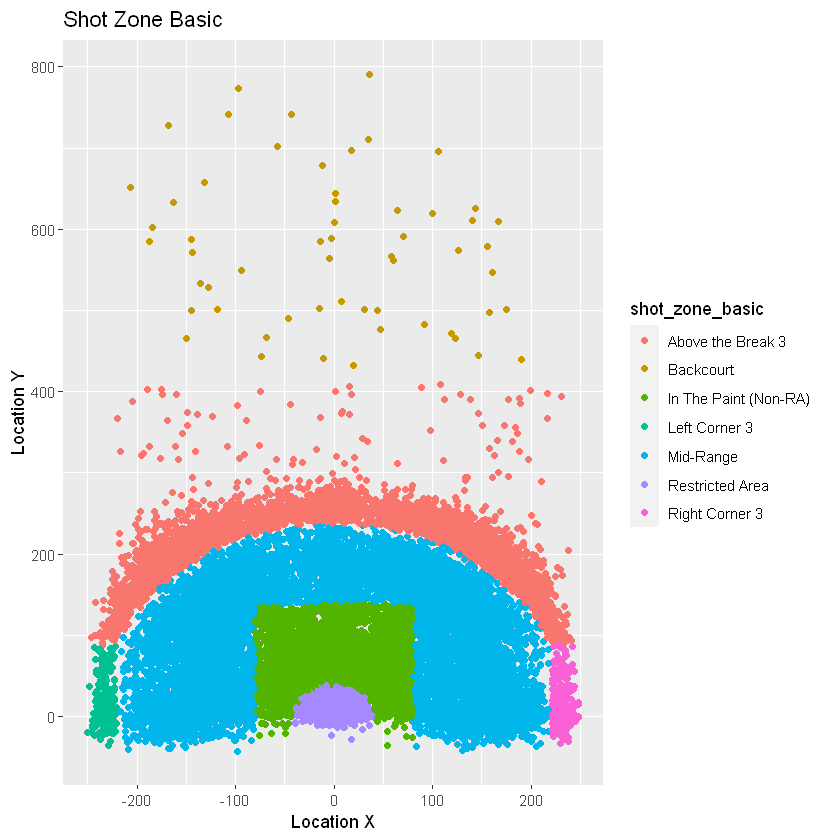

```r
ggplot(data,aes(x=loc_x,y=loc_y,color=shot_zone_basic)) + geom_point() +
labs(title= "Shot Zone Basic", x="Location X",y="Location Y")
```

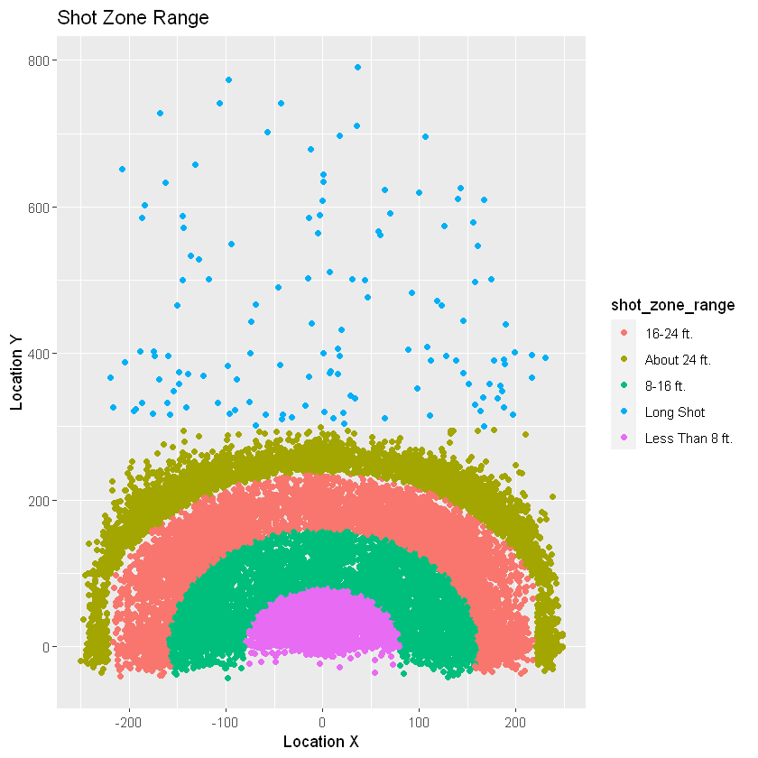

```r
ggplot(data,aes(x=loc_x,y=loc_y,color=shot_zone_range)) + geom_point() +
labs(title= "Shot Zone Range", x="Location X",y="Location Y")
```

```r
features2 <- data[,c(-10:-1,-13,-14,-15,-17,-19,-24:-21)]
features3 <- data[,c(-6:-1,-9,-10,-14,-15,-24:-17,-26)]
```

```r
glm_test2 <- glm(shot_made_flag~.,data=features2)
summary(glm_test2)
```

```
Call:
glm(formula = shot_made_flag ~ ., data = features2)

Deviance Residuals:
    Min       1Q   Median       3Q      Max
-1.0053  -0.3534  -0.2715   0.4429   0.9769
---
Signif. codes:  0 '***' 0.001 '**' 0.01 '*' 0.05 '.' 0.1 ' ' 1
...
(Dispersion parameter for gaussian family taken to be 0.2107268)

    Null deviance: 5714.7  on 23126  degrees of freedom
Residual deviance: 4853.0  on 23030  degrees of freedom
AIC: 29717

Number of Fisher Scoring iterations: 2
```

```r
glm_test3 <- glm(shot_made_flag~.,data=features3)
summary(glm_test3)
```

```
Call:
glm(formula = shot_made_flag ~ ., data = features3)

Deviance Residuals:
    Min       1Q   Median       3Q      Max
-1.0013  -0.3502  -0.2788   0.4373   0.8434
....
Signif. codes:  0 '***' 0.001 '**' 0.01 '*' 0.05 '.' 0.1 ' ' 1

(Dispersion parameter for gaussian family taken to be 0.2115899)

    Null deviance: 5714.7  on 23126  degrees of freedom
Residual deviance: 4871.0  on 23021  degrees of freedom
AIC: 29821

Number of Fisher Scoring iterations: 2
```

### Models

#### 1) Random Forest

While building random forest models, cross-validation with 10 fold will be used by caret package. Since the competition of the project will be measured by ROC, the models will use ‘ROC’ as metric. There are many observations and many attributes with plenty of levels in the data. Therefore, method of ranger will be used because it is faster than method of randomForest.

##### 1.1) FEATURES 2

```r
control1 <- trainControl(method="cv",
                        number=10,
                        summaryFunction=twoClassSummary,
                        classProbs=TRUE)
```

```r
model <- train(shot_made_flag ~.-season,
               data = features2,
               method = 'ranger',
               metric = 'ROC',
               trControl = control1,
               tuneGrid = expand.grid(.mtry=3:8,.splitrule="gini",.min.node.size=c(1:3)*5))
model
```

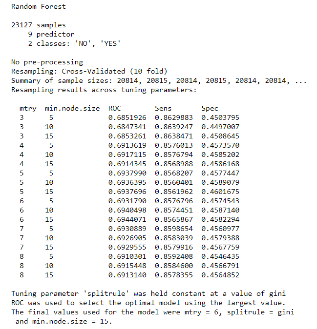

In model, mtry values of 3,4,5,6,7, and 8 were used. Also, values of 5, 10, and 15 were used as min.node.size. The best ROC value is 0.694. Next, second model will be built below.

```r
model2 <- train(shot_made_flag ~.-season,
               data = features2,
               method = 'ranger',
               metric = 'ROC',
               trControl = control1,
               tuneGrid = expand.grid(.mtry=3:8,.splitrule="gini",.min.node.size=c(1:3)*50))
```

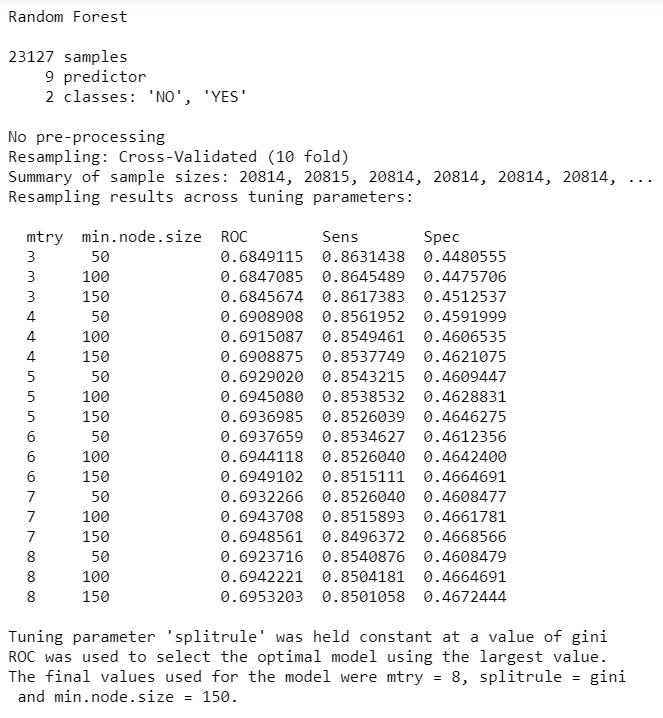

In model2, mtry values of 3,4,5,6,7, and 8 were used again. Then, values of 50, 100, and 150 were used as min.node.size in order to check whether the result is improved. The best ROC value is 0.695, which is slightly higher than first model. Next, the parameter of ntree will be changed in a for loop.

```r
models <- list()
for(ntree in (4:9)*100){
    model <- train(shot_made_flag ~.-season,
                data = features2,
                method = 'ranger',
                metric = 'ROC',
                trControl = control1,
                tuneGrid = expand.grid(.mtry=3:8,.splitrule="gini",.min.node.size=c(3:5)*100),
                num.trees=ntree)
    models[[toString(ntree)]] <- model
}
models
```

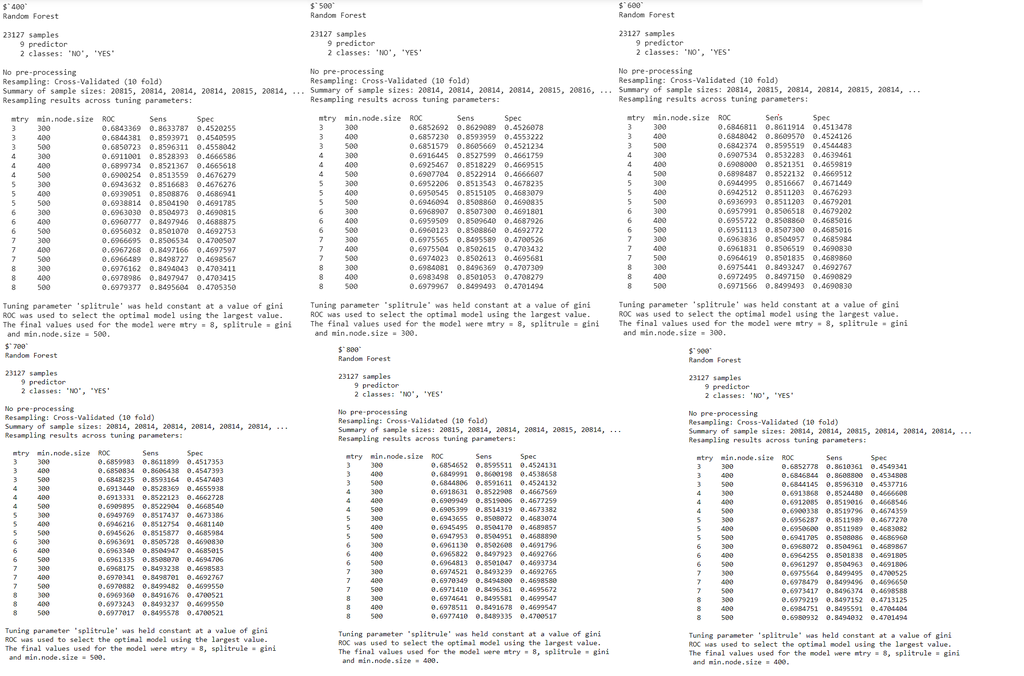

In models list, there are 6 different models with different size of ntree. Also, values of 300, 400, and 500 were used as min.node.size while values of mtry parameter did not change. The best ROC value is approximately 0.698. Features 3 will be modeled in the next step.

##### 1.2) FEATURES 3

```r
 model_f3 <- train(shot_made_flag ~.,
                data = features3,
                method = 'ranger',
                metric = 'ROC',
                trControl = control1,
                tuneGrid = expand.grid(.mtry=3:8,.splitrule="gini",.min.node.size=c(1:3)*100),
                num.trees=500)
model_f3
```

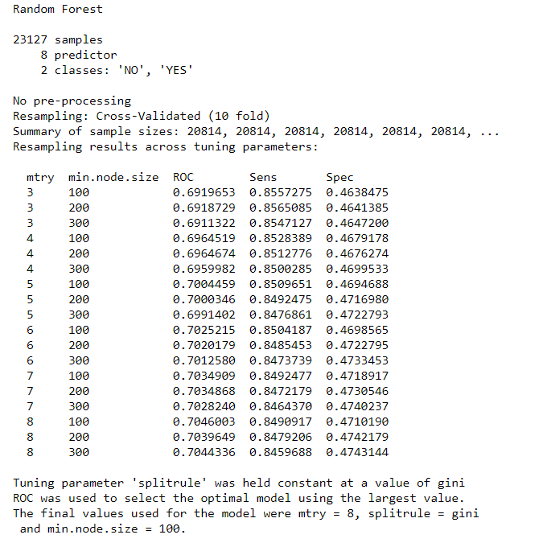

In model_f3, training set was features3. mtry values of 3,4,5,6,7, and 8 were used and values of 100, 200, and 300 were used as min.node.size. The best ROC value is 0.705. Next model will be build with min.node.size values of 400, 500, and 600.

```r
 model_f3_2 <- train(shot_made_flag ~.,
                data = features3,
                method = 'ranger',
                metric = 'ROC',
                trControl = control1,
                tuneGrid = expand.grid(.mtry=3:8,.splitrule="gini",.min.node.size=c(4:6)*100),
                num.trees=500)
model_f3_2
```

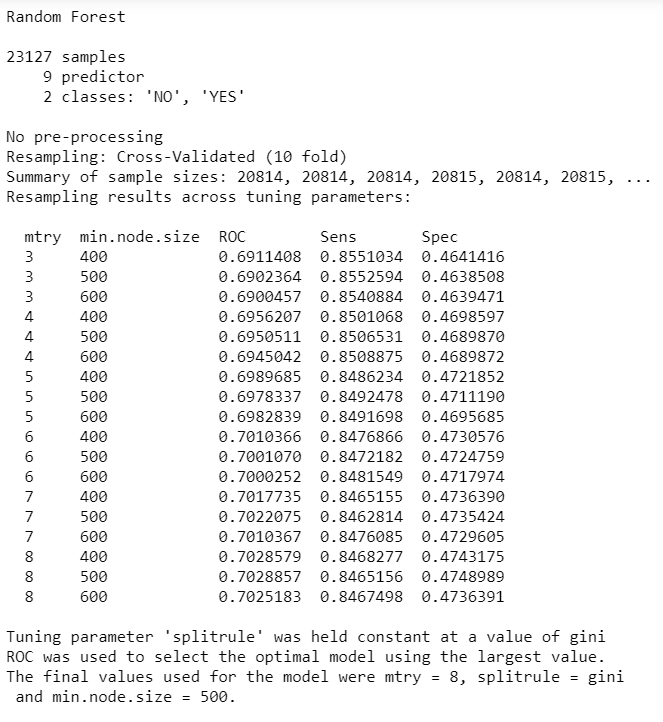

The best result is approximately 0.703 which is slightly worse than previous model.

```r
 model_f3_3 <- train(shot_made_flag ~.,
                data = features3,
                method = 'ranger',
                metric = 'ROC',
                trControl = control1,
                tuneGrid = expand.grid(.mtry=3:8,.splitrule="gini",.min.node.size=c(1:3)*50),
                num.trees=500)
model_f3_3
```

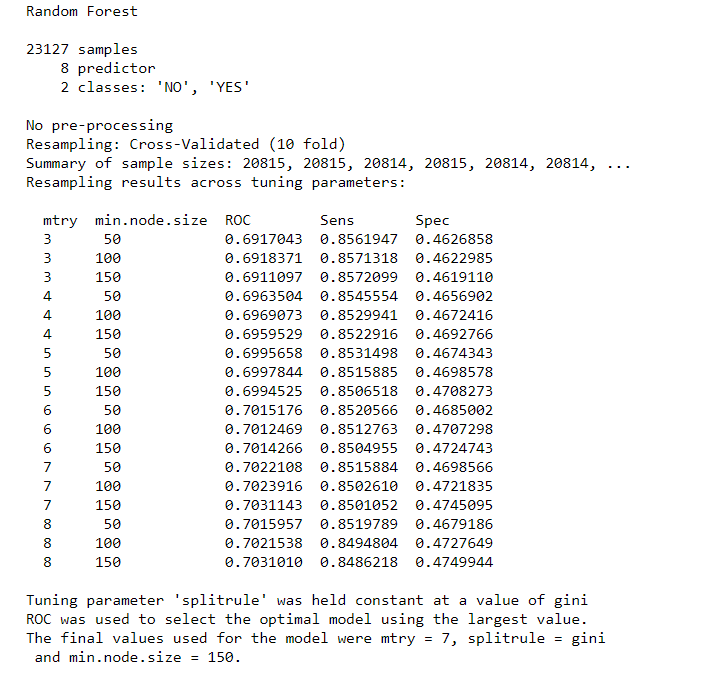

```r
model_opt_rf <- train(shot_made_flag ~.,
                data = features3,
                method = 'ranger',
                metric = 'ROC',
                trControl = control1,
                tuneGrid = expand.grid(.mtry=8,.splitrule="gini",.min.node.size=150),
                num.trees=500)
model_opt_rf
```

```
Random Forest

23127 samples
    8 predictor
    2 classes: 'NO', 'YES'

No pre-processing
Resampling: Cross-Validated (10 fold)
Summary of sample sizes: 20814, 20814, 20815, 20814, 20814, 20814, ...
Resampling results:

  ROC        Sens       Spec
  0.7026908  0.8472933  0.473541

Tuning parameter 'mtry' was held constant at a value of 8
Tuning
 parameter 'splitrule' was held constant at a value of gini
Tuning
 parameter 'min.node.size' was held constant at a value of 150
```

```r
predicts_rf <- predict(model_opt_rf,newdata=data_test,type="prob")
sub1 <- data.table(shot_id=data_test$V1,shot_made_flag=predicts_rf[,2])
fwrite(sub1,file="sub1.csv")
```

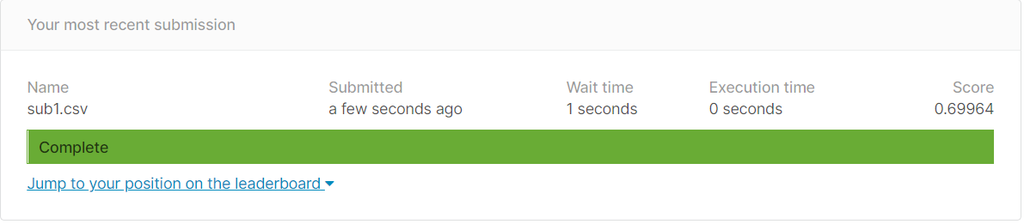

Predictions with the optimum Random Forest model has submitted to Kaggle and gave AUC value of 0.69964. Extreme gradient boosting algorithm will be used in the next step to obtain a improvement model and better AUC values.

### 2) Gradient Boosting Machines

Again, cross validation with 10 fold will be used to built GBM models. In caret library, xgbTree will be used because it gives the results faster than gbm method. Moreover, ROC will be the measurement of the models.

##### 2.1) FEATURES 2

```r
grid1 <- expand.grid(nrounds = 100,
                     max_depth = c(5,15,30),
                     eta = c(1,4,8)*0.01,
                     gamma=0,
                     colsample_bytree= 0.9,
                     min_child_weight= c(5,15,30),
                     subsample= 0.9)

model_xgb <- train(shot_made_flag ~.,
                data = features2,
                method = 'xgbTree',
                metric = 'ROC',
                trControl = control1,
                tuneGrid = grid1)
```

```r
model_xgb
```

```
eXtreme Gradient Boosting

23127 samples
    8 predictor
    2 classes: 'NO', 'YES'

No pre-processing
Resampling: Cross-Validated (10 fold)
Summary of sample sizes: 20814, 20814, 20815, 20814, 20815, 20814, ...
Resampling results across tuning parameters:

  eta   max_depth  min_child_weight  ROC        Sens       Spec
  0.01   5          5                0.7007655  0.8467462  0.4719919
  0.01   5         15                0.6999567  0.8474487  0.4716042
  0.01   5         30                0.6985525  0.8415934  0.4755777
  0.01  15          5                0.6920162  0.8490102  0.4623970
  0.01  15         15                0.6948850  0.8506493  0.4661764
  0.01  15         30                0.6958546  0.8424521  0.4750931
  0.01  30          5                0.6882400  0.8316004  0.4732521
  0.01  30         15                0.6938981  0.8482296  0.4678245
  0.01  30         30                0.6956172  0.8420618  0.4750934
  0.04   5          5                0.7025385  0.8496347  0.4707318
  0.04   5         15                0.7010818  0.8470583  0.4717975
  0.04   5         30                0.6997923  0.8411249  0.4757714
  0.04  15          5                0.6902858  0.8362845  0.4681151
  0.04  15         15                0.6940047  0.8440917  0.4672438
  0.04  15         30                0.6952402  0.8444821  0.4680177
  0.04  30          5                0.6811559  0.7930341  0.4902121
  0.04  30         15                0.6911457  0.8290243  0.4784856
  0.04  30         30                0.6945245  0.8374558  0.4723797
  0.08   5          5                0.7003590  0.8522892  0.4658859
  0.08   5         15                0.6986886  0.8503373  0.4669513
  0.08   5         30                0.6980075  0.8428423  0.4741241
  0.08  15          5                0.6843612  0.8103664  0.4845907
  0.08  15         15                0.6908130  0.8247315  0.4766437
  0.08  15         30                0.6918842  0.8324599  0.4733487
  0.08  30          5                0.6712167  0.7564189  0.5062028
  0.08  30         15                0.6849803  0.7964691  0.4929249
  0.08  30         30                0.6902810  0.8203589  0.4805218

Tuning parameter 'nrounds' was held constant at a value of 100
Tuning
 parameter 'colsample_bytree' was held constant at a value of 0.9

Tuning parameter 'subsample' was held constant at a value of 0.9
ROC was used to select the optimal model using the largest value.
The final values used for the model were nrounds = 100, max_depth = 5, eta
 = 0.04, gamma = 0, colsample_bytree = 0.9, min_child_weight = 5 and
 subsample = 0.9.
```

Different parameters were used in grid and model_xgb was built with them. The ROC value of best model is 0.702. Next, features3 will be the training set and gbm models will be built by it.

##### 2.2) FEATURES 3

```r
grid2 <- expand.grid(nrounds = 100,
                     max_depth = c(5,10,15),
                     eta = c(1,4,8)*0.01,
                     gamma=0,
                     colsample_bytree= 0.9,
                     min_child_weight= c(5,15,30),
                     subsample= 0.9)

model_xgb2 <- train(shot_made_flag ~.,
                data = features3,
                method = 'xgbTree',
                metric = 'ROC',
                trControl = control1,
                tuneGrid = grid1)
```

```r
model_xgb2
```

```
eXtreme Gradient Boosting

23127 samples
    8 predictor
    2 classes: 'NO', 'YES'

No pre-processing
Resampling: Cross-Validated (10 fold)
Summary of sample sizes: 20814, 20814, 20815, 20815, 20815, 20814, ...
Resampling results across tuning parameters:

  eta   max_depth  min_child_weight  ROC        Sens       Spec
  0.01   5          5                0.7010607  0.8466687  0.4722827
  0.01   5         15                0.7023754  0.8472931  0.4722826
  0.01   5         30                0.7007273  0.8411258  0.4763531
  0.01  15          5                0.6985553  0.8497138  0.4660805
  0.01  15         15                0.7008726  0.8512752  0.4667572
  0.01  15         30                0.7018592  0.8412040  0.4756738
  0.01  30          5                0.6958418  0.8354272  0.4776138
  0.01  30         15                0.7000886  0.8469811  0.4696654
  0.01  30         30                0.7008362  0.8402672  0.4753834
  0.04   5          5                0.7045096  0.8485427  0.4698598
  0.04   5         15                0.7049241  0.8493230  0.4699559
  0.04   5         30                0.7027863  0.8422188  0.4751895
  0.04  15          5                0.6973274  0.8333974  0.4768387
  0.04  15         15                0.7007841  0.8408918  0.4753844
  0.04  15         30                0.7022401  0.8398768  0.4739295
  0.04  30          5                0.6919438  0.7988903  0.5007780
  0.04  30         15                0.6988954  0.8234824  0.4866267
  0.04  30         30                0.7021021  0.8346462  0.4800354
  0.08   5          5                0.7044468  0.8541639  0.4651103
  0.08   5         15                0.7049620  0.8525241  0.4678240
  0.08   5         30                0.7037428  0.8455761  0.4740267
  0.08  15          5                0.6923821  0.7993588  0.4951556
  0.08  15         15                0.6985683  0.8183300  0.4937991
  0.08  15         30                0.7001850  0.8251221  0.4869166
  0.08  30          5                0.6825221  0.7636811  0.5144415
  0.08  30         15                0.6932146  0.7890536  0.5070763
  0.08  30         30                0.6977778  0.8121622  0.4957358

Tuning parameter 'nrounds' was held constant at a value of 100
Tuning
 parameter 'colsample_bytree' was held constant at a value of 0.9

Tuning parameter 'subsample' was held constant at a value of 0.9
ROC was used to select the optimal model using the largest value.
The final values used for the model were nrounds = 100, max_depth = 5, eta
 = 0.08, gamma = 0, colsample_bytree = 0.9, min_child_weight = 15 and
 subsample = 0.9.
```

```r
grid3 <- expand.grid(nrounds = c(100,150),
                     max_depth = c(1,2,3,4),
                     eta = c(5,6,7,9)*0.01,
                     gamma=0,
                     colsample_bytree= 0.9,
                     min_child_weight= c(15,20,25,35),
                     subsample= 0.9)

model_xgb3 <- train(shot_made_flag ~.,
                data = features3,
                method = 'xgbTree',
                metric = 'ROC',
                trControl = control1,
                tuneGrid = grid3)
```

```r
model_xgb3
```

```
eXtreme Gradient Boosting

23127 samples
    8 predictor
    2 classes: 'NO', 'YES'

No pre-processing
Resampling: Cross-Validated (10 fold)
Summary of sample sizes: 20814, 20814, 20814, 20815, 20814, 20814, ...
Resampling results across tuning parameters:

  eta   max_depth  min_child_weight  nrounds  ROC        Sens       Spec
  0.05  1          15                100      0.6753986  0.8419081  0.4753838
  0.05  1          15                150      0.6847939  0.8420642  0.4753838
  0.05  1          20                100      0.6754605  0.8419081  0.4753838
  0.05  1          20                150      0.6847279  0.8421422  0.4753838
  0.05  1          25                100      0.6763612  0.8419081  0.4753838
  0.05  1          25                150      0.6860617  0.8419081  0.4753838
  0.05  1          35                100      0.6760248  0.8419081  0.4753838
  0.05  1          35                150      0.6853214  0.8419081  0.4752868
  0.05  2          15                100      0.6960922  0.8454990  0.4720887
  0.05  2          15                150      0.6981669  0.8490125  0.4706350
  0.05  2          20                100      0.6958593  0.8460454  0.4716042
  0.05  2          20                150      0.6983129  0.8489344  0.4704410
  0.05  2          25                100      0.6954736  0.8450307  0.4721856
  0.05  2          25                150      0.6976850  0.8489344  0.4705380
  0.05  2          35                100      0.6955172  0.8419081  0.4753838
  0.05  2          35                150      0.6973997  0.8420642  0.4753838
  0.05  3          15                100      0.7009255  0.8489344  0.4706350
  0.05  3          15                150      0.7017378  0.8494809  0.4705381
  0.05  3          20                100      0.7008235  0.8489344  0.4706350
  0.05  3          20                150      0.7017246  0.8494809  0.4700534
  0.05  3          25                100      0.7005364  0.8489344  0.4706350
  0.05  3          25                150      0.7012710  0.8495589  0.4698597
  0.05  3          35                100      0.6994051  0.8419081  0.4752869
  0.05  3          35                150      0.7001187  0.8423764  0.4747053
  0.05  4          15                100      0.7030007  0.8482318  0.4706353
  0.05  4          15                150      0.7036444  0.8501054  0.4685997
  0.05  4          20                100      0.7034941  0.8494028  0.4699564
  0.05  4          20                150      0.7040592  0.8508861  0.4685995
```

[output cut: 95 more lines]

```
  0.09  4          20                150      0.7037389  0.8520572  0.4655948
  0.09  4          25                100      0.7030480  0.8508862  0.4706348
  0.09  4          25                150      0.7040415  0.8516670  0.4679210
  0.09  4          35                100      0.7023002  0.8433131  0.4734456
  0.09  4          35                150      0.7026119  0.8450309  0.4711190

Tuning parameter 'gamma' was held constant at a value of 0
Tuning
 parameter 'colsample_bytree' was held constant at a value of 0.9

Tuning parameter 'subsample' was held constant at a value of 0.9
ROC was used to select the optimal model using the largest value.
The final values used for the model were nrounds = 100, max_depth = 4, eta
 = 0.09, gamma = 0, colsample_bytree = 0.9, min_child_weight = 15 and
 subsample = 0.9.
```

```r
grid4 <- expand.grid(nrounds = c(150,200),
                     max_depth = c(4,5,6,7),
                     eta = c(8,9,10,11,12)*0.01,
                     gamma=0,
                     colsample_bytree= 0.9,
                     min_child_weight= c(10,15,20,25),
                     subsample= 0.9)

model_xgb4 <- train(shot_made_flag ~.,
                data = features3,
                method = 'xgbTree',
                metric = 'ROC',
                trControl = control1,
                tuneGrid = grid4)
```

```r
model_xgb4
```

```
eXtreme Gradient Boosting

23127 samples
    8 predictor
    2 classes: 'NO', 'YES'

No pre-processing
Resampling: Cross-Validated (10 fold)
Summary of sample sizes: 20814, 20814, 20814, 20815, 20814, 20815, ...
Resampling results across tuning parameters:

  eta   max_depth  min_child_weight  nrounds  ROC        Sens       Spec
  0.08  4          10                150      0.7030740  0.8544761  0.4648173
  0.08  4          10                200      0.7026417  0.8540077  0.4650110
  0.08  4          15                150      0.7035607  0.8522903  0.4666591
  0.08  4          15                200      0.7029746  0.8522904  0.4644301
  0.08  4          20                150      0.7040852  0.8528370  0.4676276
  0.08  4          20                200      0.7035407  0.8528367  0.4667553
  0.08  4          25                150      0.7023470  0.8518221  0.4678219
  0.08  4          25                200      0.7022304  0.8526808  0.4665622
  0.08  5          10                150      0.7025982  0.8528370  0.4653019
  0.08  5          10                200      0.7023092  0.8493236  0.4660775
  0.08  5          15                150      0.7041383  0.8506510  0.4670471
  0.08  5          15                200      0.7037179  0.8477622  0.4675314
  0.08  5          20                150      0.7033741  0.8525246  0.4672402
  0.08  5          20                200      0.7029077  0.8510412  0.4690818
  0.08  5          25                150      0.7030794  0.8527588  0.4677249
  0.08  5          25                200      0.7021702  0.8507290  0.4682100
  0.08  6          10                150      0.7016779  0.8506508  0.4674340
  0.08  6          10                200      0.7008620  0.8426104  0.4714083
  0.08  6          15                150      0.7033281  0.8468255  0.4700509
  0.08  6          15                200      0.7023332  0.8419856  0.4728620
  0.08  6          20                150      0.7026803  0.8486210  0.4698579
  0.08  6          20                200      0.7021276  0.8421412  0.4732502
  0.08  6          25                150      0.7025139  0.8504168  0.4694692
  0.08  6          25                200      0.7014549  0.8451860  0.4720864
  0.08  7          10                150      0.7024943  0.8451083  0.4734435
  0.08  7          10                200      0.7011272  0.8348809  0.4792585
  0.08  7          15                150      0.7027368  0.8421419  0.4732500
  0.08  7          15                200      0.7007855  0.8345692  0.4784842
```

[output cut: 127 more lines]

```
  0.12  7          15                200      0.6970832  0.8148949  0.4944760
  0.12  7          20                150      0.6995782  0.8307436  0.4825542
  0.12  7          20                200      0.6987579  0.8202036  0.4913739
  0.12  7          25                150      0.7001331  0.8322266  0.4822636
  0.12  7          25                200      0.6990758  0.8219987  0.4896303

Tuning parameter 'gamma' was held constant at a value of 0
Tuning
 parameter 'colsample_bytree' was held constant at a value of 0.9

Tuning parameter 'subsample' was held constant at a value of 0.9
ROC was used to select the optimal model using the largest value.
The final values used for the model were nrounds = 150, max_depth = 5, eta
 = 0.09, gamma = 0, colsample_bytree = 0.9, min_child_weight = 20 and
 subsample = 0.9.
```

```r
grid5 <- expand.grid(nrounds = 100,
                     max_depth = 5,
                     eta = 0.08,
                     gamma=0,
                     colsample_bytree= 0.9,
                     min_child_weight= 20,
                     subsample= 0.9)

model_xgb_opt <- train(shot_made_flag ~.,
                data = features3,
                method = 'xgbTree',
                metric = 'ROC',
                trControl = control1,
                tuneGrid = grid5)
```

```r
model_xbg_opt
```

```
eXtreme Gradient Boosting

23127 samples
    8 predictor
    2 classes: 'NO', 'YES'

No pre-processing
Resampling: Cross-Validated (10 fold)
Summary of sample sizes: 20814, 20814, 20815, 20814, 20814, 20815, ...
Resampling results:

  ROC       Sens      Spec
  0.703458  0.851121  0.4673424

Tuning parameter 'nrounds' was held constant at a value of 100
Tuning
 held constant at a value of 20
Tuning parameter 'subsample' was held
 constant at a value of 0.9
```

```r
predicts_xgb <- predict(model_xgb_opt,newdata=data_test,type="prob")
sub2 <- data.table(shot_id=data_test$V1,shot_made_flag=predicts_xgb[,2])
fwrite(sub2,file="sub2.csv")
```

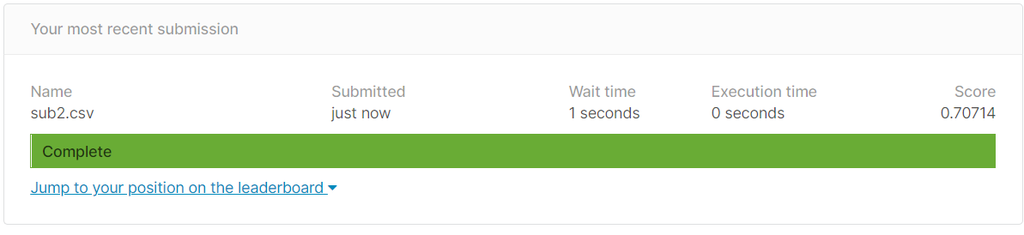

##### 2.3) An Improvement Step

After searching for improvements, court locations could influence the shot accuracy because of the crowd in the court. So, court locations, home or away match, is subtracted from the matchup column. Matchups with “@” symbol indicates away matches while matchups with “vs.” symbol indicates home matches. A binary variable is_home is added to the data to improve the model.

```r
grid6 <- expand.grid(nrounds = 100,
                     max_depth = c(4,5,6),
                     eta = c(0.06,0.08,0.1),
                     gamma=0,
                     colsample_bytree= 0.9,
                     min_child_weight= c(10,15,20),
                     subsample= 0.9)

model_xgb6 <- train(shot_made_flag ~.,
                data = features3,
                method = 'xgbTree',
                metric = 'ROC',
                trControl = control1,
                tuneGrid = grid6)
```

```r
model_xgb6
```

```
eXtreme Gradient Boosting

23127 samples
    9 predictor
    2 classes: 'NO', 'YES'

No pre-processing
Resampling: Cross-Validated (10 fold)
Summary of sample sizes: 20815, 20814, 20814, 20815, 20814, 20814, ...
Resampling results across tuning parameters:

  eta   max_depth  min_child_weight  ROC        Sens       Spec
  0.06  4          10                0.7054858  0.8526817  0.4676278
  0.06  4          15                0.7051420  0.8512765  0.4680159
  0.06  4          20                0.7055533  0.8506521  0.4685976
  0.06  5          10                0.7075718  0.8550238  0.4658833
  0.06  5          15                0.7067502  0.8526819  0.4679192
  0.06  5          20                0.7070567  0.8531502  0.4663687
  0.06  6          10                0.7070117  0.8558830  0.4656892
  0.06  6          15                0.7060130  0.8536968  0.4658840
  0.06  6          20                0.7070843  0.8538528  0.4672409
  0.08  4          10                0.7062804  0.8554142  0.4657866
  0.08  4          15                0.7055926  0.8521355  0.4676281
  0.08  4          20                0.7056508  0.8521354  0.4663682
  0.08  5          10                0.7064313  0.8567415  0.4653023
  0.08  5          15                0.7058468  0.8538528  0.4654961
  0.08  5          20                0.7064469  0.8545555  0.4662716
  0.08  6          10                0.7070170  0.8572099  0.4652047
  0.08  6          15                0.7061643  0.8553362  0.4661745
  0.08  6          20                0.7072669  0.8561951  0.4664648
  0.10  4          10                0.7064929  0.8569759  0.4640419
  0.10  4          15                0.7058507  0.8543992  0.4656896
  0.10  4          20                0.7060571  0.8542431  0.4665622
  0.10  5          10                0.7054054  0.8572100  0.4647203
  0.10  5          15                0.7056968  0.8561950  0.4643328
  0.10  5          20                0.7053618  0.8564293  0.4646247
  0.10  6          10                0.7048456  0.8569756  0.4650110
  0.10  6          15                0.7052368  0.8547114  0.4665625
  0.10  6          20                0.7063241  0.8536966  0.4691797

Tuning parameter 'nrounds' was held constant at a value of 100
Tuning
 parameter 'colsample_bytree' was held constant at a value of 0.9

Tuning parameter 'subsample' was held constant at a value of 0.9
ROC was used to select the optimal model using the largest value.
The final values used for the model were nrounds = 100, max_depth = 5, eta
 = 0.06, gamma = 0, colsample_bytree = 0.9, min_child_weight = 10 and
 subsample = 0.9.
```

```r
grid7 <- expand.grid(nrounds = 100,
                     max_depth = c(4,5,6),
                     eta = c(0.03,0.04,0.05),
                     gamma=0,
                     colsample_bytree= 0.9,
                     min_child_weight= c(10,15,20),
                     subsample= 0.9)

model_xgb7 <- train(shot_made_flag ~.,
                data = features3,
                method = 'xgbTree',
                metric = 'ROC',
                trControl = control1,
                tuneGrid = grid7)
```

```r
model_xgb7
```

```
eXtreme Gradient Boosting

23127 samples
    9 predictor
    2 classes: 'NO', 'YES'

No pre-processing
Resampling: Cross-Validated (10 fold)
Summary of sample sizes: 20815, 20816, 20814, 20814, 20814, 20814, ...
Resampling results across tuning parameters:

  eta   max_depth  min_child_weight  ROC        Sens       Spec
  0.03  4          10                0.7039080  0.8462792  0.4724765
  0.03  4          15                0.7046260  0.8460450  0.4719922
  0.03  4          20                0.7042796  0.8457323  0.4719922
  0.03  5          10                0.7060108  0.8474504  0.4719925
  0.03  5          15                0.7063208  0.8481529  0.4708291
  0.03  5          20                0.7062307  0.8483089  0.4706354
  0.03  6          10                0.7068335  0.8494021  0.4700536
  0.03  6          15                0.7060405  0.8494802  0.4704414
  0.03  6          20                0.7060020  0.8494803  0.4704413
  0.04  4          10                0.7047487  0.8495585  0.4696658
  0.04  4          15                0.7048803  0.8490898  0.4708290
  0.04  4          20                0.7047601  0.8486993  0.4705387
  0.04  5          10                0.7056809  0.8514319  0.4698602
  0.04  5          15                0.7064883  0.8496362  0.4699567
  0.04  5          20                0.7070007  0.8495580  0.4696663
  0.04  6          10                0.7067710  0.8519786  0.4672429
  0.04  6          15                0.7068073  0.8510414  0.4686966
  0.04  6          20                0.7065698  0.8503388  0.4681155
  0.05  4          10                0.7046137  0.8517443  0.4691813
  0.05  4          15                0.7048295  0.8497924  0.4700538
  0.05  4          20                0.7047853  0.8497925  0.4695693
  0.05  5          10                0.7065905  0.8525249  0.4680184
  0.05  5          15                0.7062740  0.8515881  0.4682122
  0.05  5          20                0.7058249  0.8516662  0.4690848
  0.05  6          10                0.7064860  0.8545549  0.4664674
  0.05  6          15                0.7063999  0.8536961  0.4681155
  0.05  6          20                0.7060541  0.8527590  0.4668558

Tuning parameter 'nrounds' was held constant at a value of 100
Tuning
 parameter 'colsample_bytree' was held constant at a value of 0.9

Tuning parameter 'subsample' was held constant at a value of 0.9
ROC was used to select the optimal model using the largest value.
The final values used for the model were nrounds = 100, max_depth = 5, eta
 = 0.04, gamma = 0, colsample_bytree = 0.9, min_child_weight = 20 and
 subsample = 0.9.
```

```r
grid_opt <- expand.grid(nrounds = 100,
                     max_depth = 5,
                     eta = 0.06,
                     gamma=0,
                     colsample_bytree= 0.8,
                     min_child_weight= 10,
                     subsample= 0.9)

model_xgb_opt2 <- train(shot_made_flag ~.,
                data = features3,
                method = 'xgbTree',
                metric = 'ROC',
                trControl = control1,
                tuneGrid = grid_opt)
```

```r
model_xgb_opt2
```

```
eXtreme Gradient Boosting

23127 samples
    9 predictor
    2 classes: 'NO', 'YES'

No pre-processing
Resampling: Cross-Validated (10 fold)
Summary of sample sizes: 20814, 20814, 20815, 20814, 20814, 20815, ...
Resampling results:

  ROC        Sens       Spec
  0.7064741  0.8536958  0.4667569

Tuning parameter 'nrounds' was held constant at a value of 100
Tuning
 held constant at a value of 10
Tuning parameter 'subsample' was held
 constant at a value of 0.9
```

After the addition of the new variable, the best model gave 0.706 ROC value which is better than the previous models.

```r
predicts_xgb2 <- predict(model_xgb_opt2,newdata=data_test,type="prob")
sub3 <- data.table(shot_id=data_test$V1,shot_made_flag=predicts_xgb2[,2])
fwrite(sub3,file="sub3.csv")
```

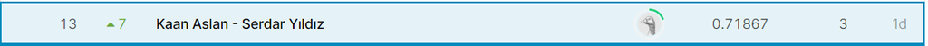

After the conclusion of the competition in the Kaggle, optimum model has the AUC value of 0.71867 and took 13th place.

### Conclusion

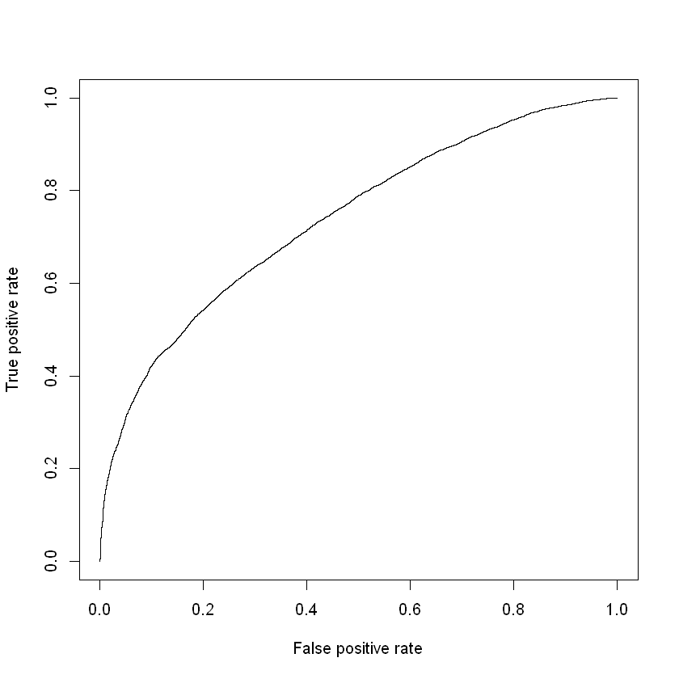

```r
res <- predict(model_xgb_opt2,newdata=features3,type="prob")
pred <- prediction(res[,2],features3$shot_made_flag)
perf <- performance(pred,"tpr","fpr")
plot(perf)
```

This assignment aims to predict Kobe Bryant’s shots with success. The data was given with 24 attributes and a target column named shot_made_flag. First, necessary data manipulations and merging processes were made. Secondly, the models were built with two different training sets containing different attributes. Caret library was used to build the models. Algorithms of Random Forest and GBM were built many times and the best result was obtained by GBM with features3 training set. Finally, the predictions on the test set were obtained and uploaded to Kaggle competition.